# Risk Factor Analysis

## Outcome Variable

**Outcome Variable:** whz

## Predictor Variables

**Intervention Variable:** hhwealth_quart

**Adjustment Set:**

- arm
- sex
- W_mage
- meducyrs
- feducyrs
- W_gagebrth
- W_birthwt
- W_birthlen
- W_nchldlt5
- W_parity
- delta_W_mage
- delta_meducyrs
- delta_feducyrs
- delta_W_gagebrth
- delta_W_birthwt
- delta_W_birthlen
- delta_W_nchldlt5
- delta_W_parity

## Stratifying Variables

The analysis was stratified on these variable(s):

- agecat
- studyid
- country

## Data Summary

| agecat | studyid | country | hhwealth_quart | n_cell | n |
| --- | --- | --- | --- | --- | --- |
| Birth | ki0047075b-MAL-ED | BANGLADESH | Wealth Q4 | 56 | 201 |
| Birth | ki0047075b-MAL-ED | BANGLADESH | Wealth Q1 | 48 | 201 |
| Birth | ki0047075b-MAL-ED | BANGLADESH | Wealth Q2 | 46 | 201 |
| Birth | ki0047075b-MAL-ED | BANGLADESH | Wealth Q3 | 51 | 201 |
| Birth | ki0047075b-MAL-ED | BRAZIL | Wealth Q4 | 10 | 57 |
| Birth | ki0047075b-MAL-ED | BRAZIL | Wealth Q1 | 20 | 57 |
| Birth | ki0047075b-MAL-ED | BRAZIL | Wealth Q2 | 16 | 57 |
| Birth | ki0047075b-MAL-ED | BRAZIL | Wealth Q3 | 11 | 57 |
| Birth | ki0047075b-MAL-ED | INDIA | Wealth Q4 | 8 | 39 |
| Birth | ki0047075b-MAL-ED | INDIA | Wealth Q1 | 13 | 39 |
| Birth | ki0047075b-MAL-ED | INDIA | Wealth Q2 | 9 | 39 |
| Birth | ki0047075b-MAL-ED | INDIA | Wealth Q3 | 9 | 39 |
| Birth | ki0047075b-MAL-ED | NEPAL | Wealth Q4 | 6 | 25 |
| Birth | ki0047075b-MAL-ED | NEPAL | Wealth Q1 | 8 | 25 |
| Birth | ki0047075b-MAL-ED | NEPAL | Wealth Q2 | 3 | 25 |
| Birth | ki0047075b-MAL-ED | NEPAL | Wealth Q3 | 8 | 25 |
| Birth | ki0047075b-MAL-ED | PERU | Wealth Q4 | 53 | 210 |
| Birth | ki0047075b-MAL-ED | PERU | Wealth Q1 | 55 | 210 |
| Birth | ki0047075b-MAL-ED | PERU | Wealth Q2 | 51 | 210 |
| Birth | ki0047075b-MAL-ED | PERU | Wealth Q3 | 51 | 210 |
| Birth | ki0047075b-MAL-ED | SOUTH AFRICA | Wealth Q4 | 17 | 95 |
| Birth | ki0047075b-MAL-ED | SOUTH AFRICA | Wealth Q1 | 26 | 95 |
| Birth | ki0047075b-MAL-ED | SOUTH AFRICA | Wealth Q2 | 24 | 95 |
| Birth | ki0047075b-MAL-ED | SOUTH AFRICA | Wealth Q3 | 28 | 95 |
| Birth | ki0047075b-MAL-ED | TANZANIA, UNITED REPUBLIC OF | Wealth Q4 | 23 | 112 |
| Birth | ki0047075b-MAL-ED | TANZANIA, UNITED REPUBLIC OF | Wealth Q1 | 26 | 112 |
| Birth | ki0047075b-MAL-ED | TANZANIA, UNITED REPUBLIC OF | Wealth Q2 | 30 | 112 |
| Birth | ki0047075b-MAL-ED | TANZANIA, UNITED REPUBLIC OF | Wealth Q3 | 33 | 112 |
| Birth | ki1000108-CMC-V-BCS-2002 | INDIA | Wealth Q4 | 32 | 86 |
| Birth | ki1000108-CMC-V-BCS-2002 | INDIA | Wealth Q1 | 13 | 86 |

[output cut: 178 more lines]

The following strata were considered:

- agecat: 24 months, studyid: ki0047075b-MAL-ED, country: BANGLADESH
- agecat: 24 months, studyid: ki0047075b-MAL-ED, country: BRAZIL
- agecat: 24 months, studyid: ki0047075b-MAL-ED, country: INDIA
- agecat: 24 months, studyid: ki0047075b-MAL-ED, country: NEPAL
- agecat: 24 months, studyid: ki0047075b-MAL-ED, country: PERU
- agecat: 24 months, studyid: ki0047075b-MAL-ED, country: SOUTH AFRICA
- agecat: 24 months, studyid: ki0047075b-MAL-ED, country: TANZANIA, UNITED REPUBLIC OF
- agecat: 24 months, studyid: ki1000108-CMC-V-BCS-2002, country: INDIA
- agecat: 24 months, studyid: ki1000108-IRC, country: INDIA
- agecat: 24 months, studyid: ki1017093b-PROVIDE, country: BANGLADESH
- agecat: 24 months, studyid: ki1066203-TanzaniaChild2, country: TANZANIA, UNITED REPUBLIC OF
- agecat: 24 months, studyid: ki1113344-GMS-Nepal, country: NEPAL
- agecat: 24 months, studyid: ki1114097-CONTENT, country: PERU
- agecat: 24 months, studyid: ki1135781-COHORTS, country: GUATEMALA
- agecat: 24 months, studyid: ki1135781-COHORTS, country: PHILIPPINES
- agecat: 24 months, studyid: ki1148112-LCNI-5, country: MALAWI
- agecat: 24 months, studyid: kiGH5241-JiVitA-3, country: BANGLADESH
- agecat: 24 months, studyid: kiGH5241-JiVitA-4, country: BANGLADESH
- agecat: 6 months, studyid: ki0047075b-MAL-ED, country: BANGLADESH
- agecat: 6 months, studyid: ki0047075b-MAL-ED, country: BRAZIL
- agecat: 6 months, studyid: ki0047075b-MAL-ED, country: INDIA
- agecat: 6 months, studyid: ki0047075b-MAL-ED, country: NEPAL
- agecat: 6 months, studyid: ki0047075b-MAL-ED, country: PERU
- agecat: 6 months, studyid: ki0047075b-MAL-ED, country: SOUTH AFRICA
- agecat: 6 months, studyid: ki0047075b-MAL-ED, country: TANZANIA, UNITED REPUBLIC OF
- agecat: 6 months, studyid: ki1000108-CMC-V-BCS-2002, country: INDIA
- agecat: 6 months, studyid: ki1000108-IRC, country: INDIA
- agecat: 6 months, studyid: ki1017093b-PROVIDE, country: BANGLADESH
- agecat: 6 months, studyid: ki1066203-TanzaniaChild2, country: TANZANIA, UNITED REPUBLIC OF
- agecat: 6 months, studyid: ki1113344-GMS-Nepal, country: NEPAL
- agecat: 6 months, studyid: ki1114097-CONTENT, country: PERU
- agecat: 6 months, studyid: ki1135781-COHORTS, country: GUATEMALA
- agecat: 6 months, studyid: ki1135781-COHORTS, country: PHILIPPINES
- agecat: 6 months, studyid: ki1148112-LCNI-5, country: MALAWI
- agecat: 6 months, studyid: kiGH5241-JiVitA-3, country: BANGLADESH
- agecat: 6 months, studyid: kiGH5241-JiVitA-4, country: BANGLADESH
- agecat: Birth, studyid: ki0047075b-MAL-ED, country: BANGLADESH
- agecat: Birth, studyid: ki0047075b-MAL-ED, country: BRAZIL
- agecat: Birth, studyid: ki0047075b-MAL-ED, country: INDIA
- agecat: Birth, studyid: ki0047075b-MAL-ED, country: NEPAL
- agecat: Birth, studyid: ki0047075b-MAL-ED, country: PERU
- agecat: Birth, studyid: ki0047075b-MAL-ED, country: SOUTH AFRICA
- agecat: Birth, studyid: ki0047075b-MAL-ED, country: TANZANIA, UNITED REPUBLIC OF
- agecat: Birth, studyid: ki1000108-CMC-V-BCS-2002, country: INDIA
- agecat: Birth, studyid: ki1000108-IRC, country: INDIA
- agecat: Birth, studyid: ki1017093b-PROVIDE, country: BANGLADESH
- agecat: Birth, studyid: ki1113344-GMS-Nepal, country: NEPAL
- agecat: Birth, studyid: ki1114097-CONTENT, country: PERU
- agecat: Birth, studyid: ki1135781-COHORTS, country: GUATEMALA
- agecat: Birth, studyid: ki1135781-COHORTS, country: PHILIPPINES
- agecat: Birth, studyid: kiGH5241-JiVitA-3, country: BANGLADESH
- agecat: Birth, studyid: kiGH5241-JiVitA-4, country: BANGLADESH

### Dropped Strata

Some strata were dropped due to rare outcomes:

- agecat: Birth, studyid: ki0047075b-MAL-ED, country: NEPAL
- agecat: Birth, studyid: ki1114097-CONTENT, country: PERU
- agecat: 24 months, studyid: ki1066203-TanzaniaChild2, country: TANZANIA, UNITED REPUBLIC OF

## Methods Detail

We’re interested in the causal parameters $E[Y_a]$ for all values of $a \in \mathcal{A}$. These parameters represent the mean outcome if, possibly contrary to fact, we intervened to set all units to have $A=a$. Under the randomization and positivity assumptions, these are identified by the statistical parameters $\psi_a=E_W[E_{Y|A,W}(Y|A=a,W)]$. In addition, we’re interested in the mean of $Y$, $E[Y]$ under no intervention (the observed mean). We will estimate these parameters by using SuperLearner to fit the relevant likelihood factors – $E_{Y|A,W}(Y|A=a,W)$ and $p(A=a|W)$, and then updating our likelihood fit using a joint TMLE.

For unadjusted analyses ($W=\{\}$), initial likelihoods were estimated using Lrnr_glm to estimate the simple $E(Y|A)$ and Lrnr_mean to estimate $p(A)$. For adjusted analyses, a small library containing Lrnr_glmnet, Lrnr_xgboost, and Lrnr_mean was used.

Having estimated these parameters, we will then use the delta method to estimate relative risks and attributable risks relative to a prespecified baseline level of $A$.

# Results Detail

## Results Plots

[figure not shown]

[figure not shown]

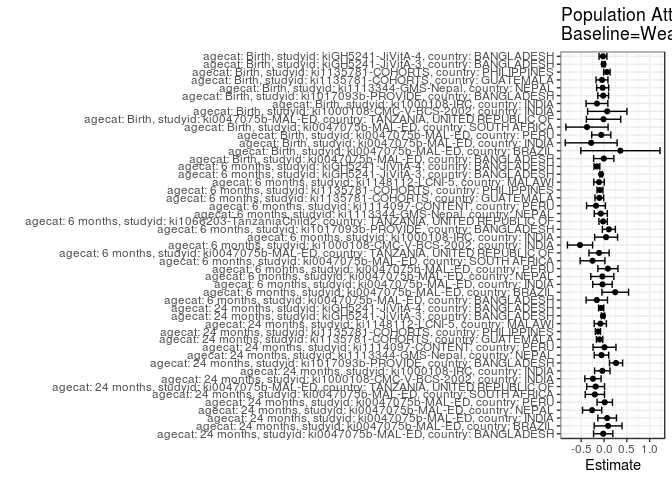

## Results Table

### Parameter: TSM

| agecat | studyid | country | intervention_level | baseline_level | estimate | ci_lower | ci_upper |
| --- | --- | --- | --- | --- | --- | --- | --- |
| Birth | ki0047075b-MAL-ED | BANGLADESH | Wealth Q4 | NA | -0.9669623 | -1.2108987 | -0.7230259 |
| Birth | ki0047075b-MAL-ED | BANGLADESH | Wealth Q1 | NA | -0.7829752 | -1.0979197 | -0.4680307 |
| Birth | ki0047075b-MAL-ED | BANGLADESH | Wealth Q2 | NA | -1.1148875 | -1.4082907 | -0.8214843 |
| Birth | ki0047075b-MAL-ED | BANGLADESH | Wealth Q3 | NA | -1.0360776 | -1.3872276 | -0.6849276 |
| Birth | ki0047075b-MAL-ED | BRAZIL | Wealth Q4 | NA | 0.1054219 | -0.8673913 | 1.0782350 |
| Birth | ki0047075b-MAL-ED | BRAZIL | Wealth Q1 | NA | 0.1019970 | -0.5452857 | 0.7492797 |
| Birth | ki0047075b-MAL-ED | BRAZIL | Wealth Q2 | NA | 0.5291712 | 0.0687613 | 0.9895811 |
| Birth | ki0047075b-MAL-ED | BRAZIL | Wealth Q3 | NA | 0.4366766 | -0.2788521 | 1.1522053 |
| Birth | ki0047075b-MAL-ED | INDIA | Wealth Q4 | NA | -0.6625000 | -1.2946579 | -0.0303421 |
| Birth | ki0047075b-MAL-ED | INDIA | Wealth Q1 | NA | -0.7753846 | -1.2462747 | -0.3044945 |
| Birth | ki0047075b-MAL-ED | INDIA | Wealth Q2 | NA | -1.2233333 | -1.8175527 | -0.6291139 |
| Birth | ki0047075b-MAL-ED | INDIA | Wealth Q3 | NA | -1.1588889 | -1.7968865 | -0.5208913 |
| Birth | ki0047075b-MAL-ED | PERU | Wealth Q4 | NA | 0.0142094 | -0.2190361 | 0.2474550 |
| Birth | ki0047075b-MAL-ED | PERU | Wealth Q1 | NA | -0.1326892 | -0.3859943 | 0.1206158 |
| Birth | ki0047075b-MAL-ED | PERU | Wealth Q2 | NA | 0.0778602 | -0.1819034 | 0.3376238 |
| Birth | ki0047075b-MAL-ED | PERU | Wealth Q3 | NA | -0.1353600 | -0.4314669 | 0.1607469 |
| Birth | ki0047075b-MAL-ED | SOUTH AFRICA | Wealth Q4 | NA | 0.2006367 | -0.2821429 | 0.6834162 |
| Birth | ki0047075b-MAL-ED | SOUTH AFRICA | Wealth Q1 | NA | -0.4200474 | -0.8907450 | 0.0506502 |
| Birth | ki0047075b-MAL-ED | SOUTH AFRICA | Wealth Q2 | NA | -0.0360350 | -0.5048387 | 0.4327688 |
| Birth | ki0047075b-MAL-ED | SOUTH AFRICA | Wealth Q3 | NA | -0.3697462 | -0.8867359 | 0.1472434 |
| Birth | ki0047075b-MAL-ED | TANZANIA, UNITED REPUBLIC OF | Wealth Q4 | NA | 0.7744253 | 0.3548018 | 1.1940488 |
| Birth | ki0047075b-MAL-ED | TANZANIA, UNITED REPUBLIC OF | Wealth Q1 | NA | 0.8852750 | 0.5425547 | 1.2279954 |
| Birth | ki0047075b-MAL-ED | TANZANIA, UNITED REPUBLIC OF | Wealth Q2 | NA | 0.8412822 | 0.4440899 | 1.2384745 |
| Birth | ki0047075b-MAL-ED | TANZANIA, UNITED REPUBLIC OF | Wealth Q3 | NA | 0.6853718 | 0.2948143 | 1.0759293 |
| Birth | ki1000108-CMC-V-BCS-2002 | INDIA | Wealth Q4 | NA | -0.5357520 | -1.1368008 | 0.0652968 |
| Birth | ki1000108-CMC-V-BCS-2002 | INDIA | Wealth Q1 | NA | -0.5274647 | -1.1896192 | 0.1346899 |
| Birth | ki1000108-CMC-V-BCS-2002 | INDIA | Wealth Q2 | NA | -0.6021570 | -1.1654702 | -0.0388438 |
| Birth | ki1000108-CMC-V-BCS-2002 | INDIA | Wealth Q3 | NA | -0.0858719 | -0.6231946 | 0.4514509 |
| Birth | ki1000108-IRC | INDIA | Wealth Q4 | NA | -0.8558943 | -1.1291933 | -0.5825952 |
| Birth | ki1000108-IRC | INDIA | Wealth Q1 | NA | -1.3310827 | -1.6464241 | -1.0157413 |

[output cut: 166 more lines]

### Parameter: E(Y)

| agecat | studyid | country | intervention_level | baseline_level | estimate | ci_lower | ci_upper |
| --- | --- | --- | --- | --- | --- | --- | --- |
| Birth | ki0047075b-MAL-ED | BANGLADESH | NA | NA | -0.9728358 | -1.1217009 | -0.8239707 |
| Birth | ki0047075b-MAL-ED | BRAZIL | NA | NA | 0.4643860 | 0.1360519 | 0.7927200 |
| Birth | ki0047075b-MAL-ED | INDIA | NA | NA | -0.9441026 | -1.2397919 | -0.6484132 |
| Birth | ki0047075b-MAL-ED | PERU | NA | NA | -0.0468095 | -0.1738806 | 0.0802616 |
| Birth | ki0047075b-MAL-ED | SOUTH AFRICA | NA | NA | -0.1729474 | -0.4186222 | 0.0727275 |
| Birth | ki0047075b-MAL-ED | TANZANIA, UNITED REPUBLIC OF | NA | NA | 0.7637500 | 0.5676177 | 0.9598823 |
| Birth | ki1000108-CMC-V-BCS-2002 | INDIA | NA | NA | -0.4648256 | -0.7643210 | -0.1653302 |
| Birth | ki1000108-IRC | INDIA | NA | NA | -1.0105831 | -1.1973019 | -0.8238643 |
| Birth | ki1017093b-PROVIDE | BANGLADESH | NA | NA | -1.2984586 | -1.3752758 | -1.2216415 |
| Birth | ki1113344-GMS-Nepal | NEPAL | NA | NA | -1.1164431 | -1.2040134 | -1.0288728 |
| Birth | ki1135781-COHORTS | GUATEMALA | NA | NA | -1.0572840 | -1.1606089 | -0.9539590 |
| Birth | ki1135781-COHORTS | PHILIPPINES | NA | NA | -0.7422912 | -0.7886598 | -0.6959226 |
| Birth | kiGH5241-JiVitA-3 | BANGLADESH | NA | NA | -0.7777103 | -0.7967006 | -0.7587201 |
| Birth | kiGH5241-JiVitA-4 | BANGLADESH | NA | NA | -0.6882498 | -0.7406539 | -0.6358456 |
| 6 months | ki0047075b-MAL-ED | BANGLADESH | NA | NA | -0.1333333 | -0.2623761 | -0.0042906 |
| 6 months | ki0047075b-MAL-ED | BRAZIL | NA | NA | 0.9720774 | 0.8078144 | 1.1363403 |
| 6 months | ki0047075b-MAL-ED | INDIA | NA | NA | -0.7102872 | -0.8371659 | -0.5834085 |
| 6 months | ki0047075b-MAL-ED | NEPAL | NA | NA | 0.1104308 | -0.0208643 | 0.2417259 |
| 6 months | ki0047075b-MAL-ED | PERU | NA | NA | 1.0512099 | 0.9285617 | 1.1738581 |
| 6 months | ki0047075b-MAL-ED | SOUTH AFRICA | NA | NA | 0.5404351 | 0.3867005 | 0.6941696 |
| 6 months | ki0047075b-MAL-ED | TANZANIA, UNITED REPUBLIC OF | NA | NA | 0.5362213 | 0.4049390 | 0.6675036 |
| 6 months | ki1000108-CMC-V-BCS-2002 | INDIA | NA | NA | -0.5026766 | -0.6536848 | -0.3516685 |
| 6 months | ki1000108-IRC | INDIA | NA | NA | -0.5989297 | -0.7344491 | -0.4634104 |
| 6 months | ki1017093b-PROVIDE | BANGLADESH | NA | NA | -0.1990907 | -0.2817968 | -0.1163845 |
| 6 months | ki1066203-TanzaniaChild2 | TANZANIA, UNITED REPUBLIC OF | NA | NA | 0.0801680 | 0.0273223 | 0.1330136 |
| 6 months | ki1113344-GMS-Nepal | NEPAL | NA | NA | -0.6038416 | -0.6899448 | -0.5177384 |
| 6 months | ki1114097-CONTENT | PERU | NA | NA | 1.0684318 | 0.9515274 | 1.1853362 |
| 6 months | ki1135781-COHORTS | GUATEMALA | NA | NA | 0.1914471 | 0.1185005 | 0.2643936 |
| 6 months | ki1135781-COHORTS | PHILIPPINES | NA | NA | -0.2938433 | -0.3352064 | -0.2524802 |
| 6 months | ki1148112-LCNI-5 | MALAWI | NA | NA | 0.4417647 | 0.3702742 | 0.5132552 |
| 6 months | kiGH5241-JiVitA-3 | BANGLADESH | NA | NA | -0.5932502 | -0.6127743 | -0.5737261 |
| 6 months | kiGH5241-JiVitA-4 | BANGLADESH | NA | NA | -0.3901595 | -0.4274150 | -0.3529041 |
| 24 months | ki0047075b-MAL-ED | BANGLADESH | NA | NA | -0.8192925 | -0.9412667 | -0.6973182 |
| 24 months | ki0047075b-MAL-ED | BRAZIL | NA | NA | 0.4626233 | 0.2567495 | 0.6684971 |
| 24 months | ki0047075b-MAL-ED | INDIA | NA | NA | -0.9516520 | -1.0670654 | -0.8362385 |
| 24 months | ki0047075b-MAL-ED | NEPAL | NA | NA | -0.3749123 | -0.4886073 | -0.2612173 |
| 24 months | ki0047075b-MAL-ED | PERU | NA | NA | 0.1111982 | -0.0118399 | 0.2342362 |
| 24 months | ki0047075b-MAL-ED | SOUTH AFRICA | NA | NA | 0.4090301 | 0.2879441 | 0.5301161 |
| 24 months | ki0047075b-MAL-ED | TANZANIA, UNITED REPUBLIC OF | NA | NA | 0.0547975 | -0.0703378 | 0.1799328 |
| 24 months | ki1000108-CMC-V-BCS-2002 | INDIA | NA | NA | -0.5571505 | -0.6585247 | -0.4557763 |
| 24 months | ki1000108-IRC | INDIA | NA | NA | -0.7458150 | -0.8368180 | -0.6548120 |
| 24 months | ki1017093b-PROVIDE | BANGLADESH | NA | NA | -0.8928670 | -0.9755153 | -0.8102187 |
| 24 months | ki1113344-GMS-Nepal | NEPAL | NA | NA | -1.1363107 | -1.2252817 | -1.0473398 |
| 24 months | ki1114097-CONTENT | PERU | NA | NA | 0.5668293 | 0.4302437 | 0.7034148 |
| 24 months | ki1135781-COHORTS | GUATEMALA | NA | NA | -0.2791396 | -0.3336899 | -0.2245893 |
| 24 months | ki1135781-COHORTS | PHILIPPINES | NA | NA | -0.6099592 | -0.6467541 | -0.5731643 |
| 24 months | ki1148112-LCNI-5 | MALAWI | NA | NA | -0.0477867 | -0.1301103 | 0.0345368 |
| 24 months | kiGH5241-JiVitA-3 | BANGLADESH | NA | NA | -1.2973086 | -1.3206115 | -1.2740057 |
| 24 months | kiGH5241-JiVitA-4 | BANGLADESH | NA | NA | -1.2231776 | -1.2550332 | -1.1913220 |

### Parameter: ATE

| agecat | studyid | country | intervention_level | baseline_level | estimate | ci_lower | ci_upper |
| --- | --- | --- | --- | --- | --- | --- | --- |
| Birth | ki0047075b-MAL-ED | BANGLADESH | Wealth Q4 | Wealth Q4 | 0.0000000 | 0.0000000 | 0.0000000 |
| Birth | ki0047075b-MAL-ED | BANGLADESH | Wealth Q1 | Wealth Q4 | 0.1839871 | -0.2144373 | 0.5824114 |
| Birth | ki0047075b-MAL-ED | BANGLADESH | Wealth Q2 | Wealth Q4 | -0.1479253 | -0.5297504 | 0.2338999 |
| Birth | ki0047075b-MAL-ED | BANGLADESH | Wealth Q3 | Wealth Q4 | -0.0691153 | -0.4965945 | 0.3583638 |
| Birth | ki0047075b-MAL-ED | BRAZIL | Wealth Q4 | Wealth Q4 | 0.0000000 | 0.0000000 | 0.0000000 |
| Birth | ki0047075b-MAL-ED | BRAZIL | Wealth Q1 | Wealth Q4 | -0.0034249 | -1.1756557 | 1.1688060 |
| Birth | ki0047075b-MAL-ED | BRAZIL | Wealth Q2 | Wealth Q4 | 0.4237494 | -0.6406283 | 1.4881270 |
| Birth | ki0047075b-MAL-ED | BRAZIL | Wealth Q3 | Wealth Q4 | 0.3312547 | -0.8847099 | 1.5472194 |
| Birth | ki0047075b-MAL-ED | INDIA | Wealth Q4 | Wealth Q4 | 0.0000000 | 0.0000000 | 0.0000000 |
| Birth | ki0047075b-MAL-ED | INDIA | Wealth Q1 | Wealth Q4 | -0.1128846 | -0.9011492 | 0.6753800 |
| Birth | ki0047075b-MAL-ED | INDIA | Wealth Q2 | Wealth Q4 | -0.5608333 | -1.4284279 | 0.3067612 |
| Birth | ki0047075b-MAL-ED | INDIA | Wealth Q3 | Wealth Q4 | -0.4963889 | -1.3945340 | 0.4017562 |
| Birth | ki0047075b-MAL-ED | PERU | Wealth Q4 | Wealth Q4 | 0.0000000 | 0.0000000 | 0.0000000 |
| Birth | ki0047075b-MAL-ED | PERU | Wealth Q1 | Wealth Q4 | -0.1468987 | -0.4914577 | 0.1976604 |
| Birth | ki0047075b-MAL-ED | PERU | Wealth Q2 | Wealth Q4 | 0.0636508 | -0.2857894 | 0.4130910 |
| Birth | ki0047075b-MAL-ED | PERU | Wealth Q3 | Wealth Q4 | -0.1495694 | -0.5269762 | 0.2278373 |
| Birth | ki0047075b-MAL-ED | SOUTH AFRICA | Wealth Q4 | Wealth Q4 | 0.0000000 | 0.0000000 | 0.0000000 |
| Birth | ki0047075b-MAL-ED | SOUTH AFRICA | Wealth Q1 | Wealth Q4 | -0.6206841 | -1.2934741 | 0.0521060 |
| Birth | ki0047075b-MAL-ED | SOUTH AFRICA | Wealth Q2 | Wealth Q4 | -0.2366716 | -0.9091334 | 0.4357901 |
| Birth | ki0047075b-MAL-ED | SOUTH AFRICA | Wealth Q3 | Wealth Q4 | -0.5703829 | -1.2778612 | 0.1370954 |
| Birth | ki0047075b-MAL-ED | TANZANIA, UNITED REPUBLIC OF | Wealth Q4 | Wealth Q4 | 0.0000000 | 0.0000000 | 0.0000000 |
| Birth | ki0047075b-MAL-ED | TANZANIA, UNITED REPUBLIC OF | Wealth Q1 | Wealth Q4 | 0.1108497 | -0.4251792 | 0.6468787 |
| Birth | ki0047075b-MAL-ED | TANZANIA, UNITED REPUBLIC OF | Wealth Q2 | Wealth Q4 | 0.0668569 | -0.5069872 | 0.6407010 |
| Birth | ki0047075b-MAL-ED | TANZANIA, UNITED REPUBLIC OF | Wealth Q3 | Wealth Q4 | -0.0890535 | -0.6566923 | 0.4785853 |
| Birth | ki1000108-CMC-V-BCS-2002 | INDIA | Wealth Q4 | Wealth Q4 | 0.0000000 | 0.0000000 | 0.0000000 |
| Birth | ki1000108-CMC-V-BCS-2002 | INDIA | Wealth Q1 | Wealth Q4 | 0.0082873 | -0.8879043 | 0.9044789 |
| Birth | ki1000108-CMC-V-BCS-2002 | INDIA | Wealth Q2 | Wealth Q4 | -0.0664051 | -0.8954443 | 0.7626342 |
| Birth | ki1000108-CMC-V-BCS-2002 | INDIA | Wealth Q3 | Wealth Q4 | 0.4498801 | -0.3581834 | 1.2579436 |
| Birth | ki1000108-IRC | INDIA | Wealth Q4 | Wealth Q4 | 0.0000000 | 0.0000000 | 0.0000000 |
| Birth | ki1000108-IRC | INDIA | Wealth Q1 | Wealth Q4 | -0.4751884 | -0.8660416 | -0.0843353 |

[output cut: 166 more lines]

### Parameter: PAR

| agecat | studyid | country | intervention_level | baseline_level | estimate | ci_lower | ci_upper |
| --- | --- | --- | --- | --- | --- | --- | --- |
| Birth | ki0047075b-MAL-ED | BANGLADESH | Wealth Q4 | NA | -0.0058735 | -0.2272435 | 0.2154964 |
| Birth | ki0047075b-MAL-ED | BRAZIL | Wealth Q4 | NA | 0.3589641 | -0.5087653 | 1.2266935 |
| Birth | ki0047075b-MAL-ED | INDIA | Wealth Q4 | NA | -0.2816026 | -0.8500282 | 0.2868230 |
| Birth | ki0047075b-MAL-ED | PERU | Wealth Q4 | NA | -0.0610190 | -0.2707516 | 0.1487137 |
| Birth | ki0047075b-MAL-ED | SOUTH AFRICA | Wealth Q4 | NA | -0.3735840 | -0.8361307 | 0.0889626 |
| Birth | ki0047075b-MAL-ED | TANZANIA, UNITED REPUBLIC OF | Wealth Q4 | NA | -0.0106753 | -0.3867318 | 0.3653811 |
| Birth | ki1000108-CMC-V-BCS-2002 | INDIA | Wealth Q4 | NA | 0.0709264 | -0.3599989 | 0.5018517 |
| Birth | ki1000108-IRC | INDIA | Wealth Q4 | NA | -0.1546888 | -0.3935150 | 0.0841373 |
| Birth | ki1017093b-PROVIDE | BANGLADESH | Wealth Q4 | NA | -0.0182998 | -0.1357175 | 0.0991179 |
| Birth | ki1113344-GMS-Nepal | NEPAL | Wealth Q4 | NA | -0.0297808 | -0.1622546 | 0.1026931 |
| Birth | ki1135781-COHORTS | GUATEMALA | Wealth Q4 | NA | -0.0448740 | -0.1758538 | 0.0861058 |
| Birth | ki1135781-COHORTS | PHILIPPINES | Wealth Q4 | NA | 0.0619540 | -0.0091472 | 0.1330552 |
| Birth | kiGH5241-JiVitA-3 | BANGLADESH | Wealth Q4 | NA | -0.0106088 | -0.0432258 | 0.0220083 |
| Birth | kiGH5241-JiVitA-4 | BANGLADESH | Wealth Q4 | NA | -0.0228813 | -0.1087011 | 0.0629384 |
| 6 months | ki0047075b-MAL-ED | BANGLADESH | Wealth Q4 | NA | -0.1587242 | -0.3931566 | 0.0757082 |
| 6 months | ki0047075b-MAL-ED | BRAZIL | Wealth Q4 | NA | 0.2462362 | -0.0455871 | 0.5380595 |
| 6 months | ki0047075b-MAL-ED | INDIA | Wealth Q4 | NA | -0.0343715 | -0.2473288 | 0.1785857 |
| 6 months | ki0047075b-MAL-ED | NEPAL | Wealth Q4 | NA | -0.0378577 | -0.2906466 | 0.2149312 |
| 6 months | ki0047075b-MAL-ED | PERU | Wealth Q4 | NA | 0.0848259 | -0.1356063 | 0.3052580 |
| 6 months | ki0047075b-MAL-ED | SOUTH AFRICA | Wealth Q4 | NA | -0.2517511 | -0.5232732 | 0.0197711 |
| 6 months | ki0047075b-MAL-ED | TANZANIA, UNITED REPUBLIC OF | Wealth Q4 | NA | -0.1086948 | -0.3298021 | 0.1124125 |
| 6 months | ki1000108-CMC-V-BCS-2002 | INDIA | Wealth Q4 | NA | -0.5263471 | -0.8025172 | -0.2501771 |
| 6 months | ki1000108-IRC | INDIA | Wealth Q4 | NA | 0.0456708 | -0.2056317 | 0.2969733 |
| 6 months | ki1017093b-PROVIDE | BANGLADESH | Wealth Q4 | NA | 0.1059414 | -0.0370813 | 0.2489642 |
| 6 months | ki1066203-TanzaniaChild2 | TANZANIA, UNITED REPUBLIC OF | Wealth Q4 | NA | -0.0198939 | -0.1119193 | 0.0721315 |
| 6 months | ki1113344-GMS-Nepal | NEPAL | Wealth Q4 | NA | -0.0709064 | -0.2140767 | 0.0722640 |
| 6 months | ki1114097-CONTENT | PERU | Wealth Q4 | NA | -0.1759407 | -0.3823053 | 0.0304239 |
| 6 months | ki1135781-COHORTS | GUATEMALA | Wealth Q4 | NA | -0.1038519 | -0.1990530 | -0.0086508 |
| 6 months | ki1135781-COHORTS | PHILIPPINES | Wealth Q4 | NA | -0.0891589 | -0.1534894 | -0.0248285 |
| 6 months | ki1148112-LCNI-5 | MALAWI | Wealth Q4 | NA | -0.1097437 | -0.2247835 | 0.0052960 |
| 6 months | kiGH5241-JiVitA-3 | BANGLADESH | Wealth Q4 | NA | -0.0647620 | -0.0932713 | -0.0362527 |
| 6 months | kiGH5241-JiVitA-4 | BANGLADESH | Wealth Q4 | NA | -0.1556327 | -0.2188659 | -0.0923996 |
| 24 months | ki0047075b-MAL-ED | BANGLADESH | Wealth Q4 | NA | -0.0177535 | -0.2289112 | 0.1934041 |
| 24 months | ki0047075b-MAL-ED | BRAZIL | Wealth Q4 | NA | 0.0897199 | -0.2155949 | 0.3950347 |
| 24 months | ki0047075b-MAL-ED | INDIA | Wealth Q4 | NA | 0.0689659 | -0.1350749 | 0.2730067 |
| 24 months | ki0047075b-MAL-ED | NEPAL | Wealth Q4 | NA | -0.2609179 | -0.4715524 | -0.0502834 |
| 24 months | ki0047075b-MAL-ED | PERU | Wealth Q4 | NA | 0.0157546 | -0.1530323 | 0.1845415 |
| 24 months | ki0047075b-MAL-ED | SOUTH AFRICA | Wealth Q4 | NA | -0.2008823 | -0.4122315 | 0.0104670 |
| 24 months | ki0047075b-MAL-ED | TANZANIA, UNITED REPUBLIC OF | Wealth Q4 | NA | -0.1843232 | -0.3807513 | 0.0121049 |
| 24 months | ki1000108-CMC-V-BCS-2002 | INDIA | Wealth Q4 | NA | -0.2425666 | -0.4206342 | -0.0644989 |
| 24 months | ki1000108-IRC | INDIA | Wealth Q4 | NA | -0.0376847 | -0.2069570 | 0.1315876 |
| 24 months | ki1017093b-PROVIDE | BANGLADESH | Wealth Q4 | NA | 0.2636550 | 0.1199998 | 0.4073103 |
| 24 months | ki1113344-GMS-Nepal | NEPAL | Wealth Q4 | NA | -0.0556613 | -0.2144420 | 0.1031195 |
| 24 months | ki1114097-CONTENT | PERU | Wealth Q4 | NA | 0.0102277 | -0.2409232 | 0.2613786 |
| 24 months | ki1135781-COHORTS | GUATEMALA | Wealth Q4 | NA | -0.0973749 | -0.1665336 | -0.0282163 |
| 24 months | ki1135781-COHORTS | PHILIPPINES | Wealth Q4 | NA | -0.1337521 | -0.1903714 | -0.0771329 |
| 24 months | ki1148112-LCNI-5 | MALAWI | Wealth Q4 | NA | -0.0811584 | -0.2148316 | 0.0525149 |
| 24 months | kiGH5241-JiVitA-3 | BANGLADESH | Wealth Q4 | NA | -0.0229746 | -0.0587565 | 0.0128074 |
| 24 months | kiGH5241-JiVitA-4 | BANGLADESH | Wealth Q4 | NA | -0.0633821 | -0.1200491 | -0.0067151 |